# pupillometry-for-linguistics-parti

#### Work supported by the National Science Foundation [Dissertation Improvement Award No:1939903](https://www.nsf.gov/awardsearch/showAward?AWD_ID=1939903&HistoricalAwards=false) awarded to Priscila López-Beltrán.

#### Special thanks to [NSF PIRE II: Translating cognitive and brain science in the laboratory and field to language learning environments](https://pire.la.psu.edu/), awarded to the Center for Language Science at The Pennsylvania State University.

## **1. What is pupillometry?**

#### Pupillometry is an online data collection technique employed in language science research. Psychological and neurological work over the past several decades has shown that the pupillary response is linked not only to changes in ambient luminance, but also to aspects of language processing.

## **2. What can you learn using the materials in this notebook?**

#### While the design of a pupillometric experiment is beyond the scope of this notebook, the materials here should provide a good first approach to analyzing pupillometric data in R.

In this notebook, we will learn how to analyze time series data. To exemplify this, we will be analyzing *pupillometry data*.

First, what is time-series data?

Time-course refers to the evolution of a measurement over time, while time-series refers to data that form a sequence ordered in time. Therefore, you do a time-course experiment and you analyze time series. In our case, pupillometry is considered time series data because data on pupil dilation are collected continuously as the experiment unfolds such that we can obtain a dynamic, continuous measurement of pupil size over a period of time.

The method used to analyze time-series data that we will learn in this notebook is called *Generalized Linear Mixed Models* (GAMMs), which can be seen as regression models which are able to model non-linear patterns in the data. For example, below, we can easily see that a regression line is unable to capture the non-linear nature of the Formant 2 trajectory:

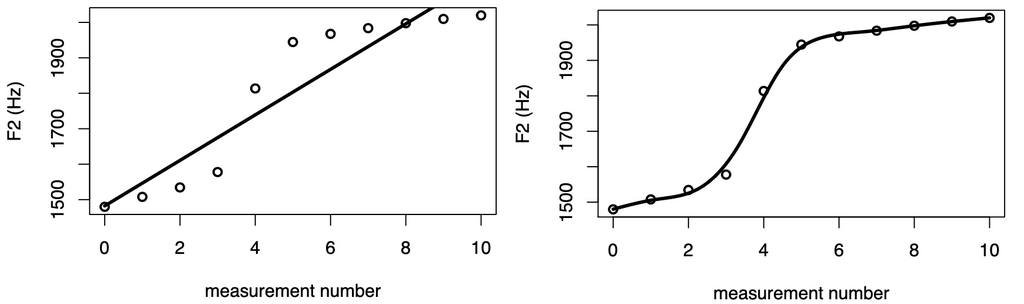

Let us refer to the slopes and intercepts of linear regression models as *parametric terms*. GAMMs differ from traditional linear regression models by allowing so-called *smooth terms* alongside parametric terms. Smooth terms are extremely flexible, that is how they can account for non-linear patterns.

In addition, similar to linear mixed effects models, GAMMs incorporate random effects. These random effects can be random intercepts and random slopes. However, GAMMs also offer a third option: *random smooths*. Random smooths are similar to random slopes, but they are more flexible than the latter: while random slopes can only capture by-group variation in linear effects, random smooths can also deal with by-group variation in non-linear effects.

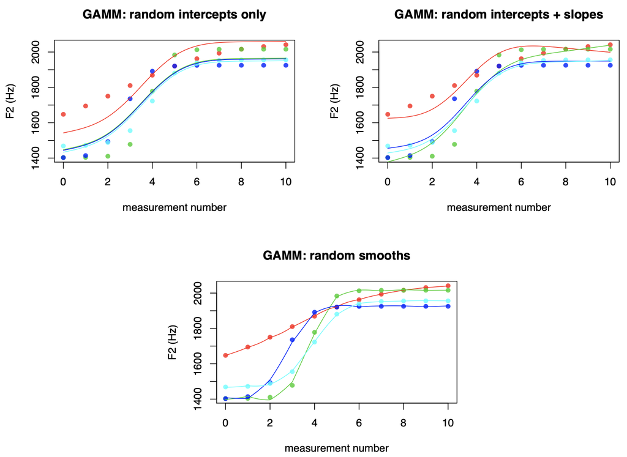

## Sample experiment: The Spanish subjunctive

In Spanish, mood selection is primarily lexically conditioned, which entails that a number of verbs (governors) govern use of the subjunctive and indicative variants. A subset of these governors are non-variable, meaning that they select the subjunctive 100% pf the times (e.g., querer). This experiment investigates heritage speakers of Spanish sensitivity to this lexical constraint.

Lexical Conditioning Experiment

1. Condition Non-variable Subjunctive (NVS) consists of a non-variable governor (in bold) followed by a subordinate verb in the subjunctive (in italics).
2. Condition Non-variable Indicative (NVI) is comprised of a non-variable governor (in bold) followed by a subordinate verb in the indicative (in italics).

**Hypothesis**: Condition NVI will elicit higher pupillary dilation in participants if they are sensitive to the lexical constraint that non-variable governors select the subjunctive categorically.

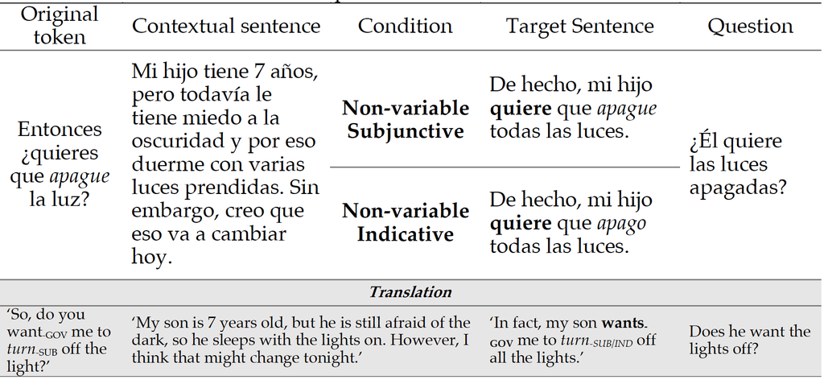

### In Part II, we will create our first GAMM.